# Exploratory Data Analysis of Tsunami Events from Seismic Data

Angel Ortiz, Rayane Cascon

2025-03-11

# Exploratory Data Analysis of Tsunami Events from Seismic Data

The aim of this study is to analyse variables related with Seismic events to create a proper dataset for tsunami prediction.

**Project:** Tsunami Prediction Analysis from Earthquake Parameters  
**Data Source:** https://www.kaggle.com/datasets/warcoder/earthquake-dataset **License:** Creative Commons Attribution 4.0 International (CC BY 4.0)  
https://creativecommons.org/licenses/by/4.0/ ***

# 1. Setup and Data Loading

## 1.1 Package Installation and Loading

```r
# Install required packages if not already installed
required_packages <- c(
  "tidyverse",
  "dplyr",
  "ggplot2",
  "factoextra",
  "GGally",
  "tidyr",
  "maps",
  "rpart",
  "cluster",
  "mclust",
  "reshape2"
)

# Check and install packages
for (pkg in required_packages) {
  if (!require(pkg, character.only = TRUE)) {
    install.packages(pkg, dependencies = TRUE)
  }
}
```

## 1.2 Load Required Libraries and Prepare Environment

```r
library(tidyverse)
library(tidyr)
library(dplyr)
library(ggplot2)
library(factoextra)
library(GGally)
library(maps)
library(rpart)
library(cluster)
library(mclust)
library(reshape2)

rm(list = ls())
```

## 1.3 Data Import

```r
knitr::opts_knit$set(root.dir = rprojroot::find_rstudio_root_file())
tsunami_data = read.csv("data/TsunamiData.csv", header= TRUE)
nrow(tsunami_data)
```

```
## [1] 1000
```

```r
str(tsunami_data)
```

```
## 'data.frame':    1000 obs. of  19 variables:
##  $ title    : chr  "M 6.5 - 42 km W of Sola, Vanuatu" "M 6.5 - 43 km S of Intipucá, El Salvador" "M 6.6 - 25 km ESE of Loncopué, Argentina" "M 7.2 - 98 km S of Sand Point, Alaska" ...
##  $ magnitude: num  6.5 6.5 6.6 7.2 7.3 6.6 6.9 7.2 6.6 7.1 ...
##  $ date_time: chr  "16-08-2023 12:47" "19-07-2023 00:22" "17-07-2023 03:05" "16-07-2023 06:48" ...
##  $ cdi      : int  7 8 7 6 0 5 4 8 6 3 ...
##  $ mmi      : int  4 6 5 6 5 4 4 6 6 4 ...
##  $ alert    : chr  "green" "yellow" "green" "green" ...
##  $ tsunami  : int  0 0 0 1 1 1 1 1 1 1 ...
##  $ sig      : int  657 775 899 860 820 802 741 804 733 777 ...
##  $ net      : chr  "us" "us" "us" "us" ...
##  $ nst      : int  114 92 70 173 79 95 136 85 50 98 ...
##  $ dmin     : num  7.177 0.679 1.634 0.907 0.879 ...
##  $ gap      : num  25 40 28 36 173 ...
##  $ magType  : chr  "mww" "mww" "mww" "mww" ...
##  $ depth    : num  193 69.7 171.4 32.6 21 ...
##  $ latitude : num  -13.9 12.8 -38.2 54.4 54.5 ...
##  $ longitude: num  167.2 -88.1 -70.4 -160.7 -160.8 ...
##  $ location : chr  "Sola, Vanuatu" "Intipucá, El Salvador" "Loncopué, Argentina" "Sand Point, Alaska" ...
##  $ continent: chr  "" "" "South America" "" ...
##  $ country  : chr  "Vanuatu" "" "Argentina" "" ...
```

```r
head(tsunami_data)
```

```
##                                                   title magnitude
## 1                      M 6.5 - 42 km W of Sola, Vanuatu       6.5
## 2              M 6.5 - 43 km S of Intipucá, El Salvador       6.5
## 3              M 6.6 - 25 km ESE of Loncopué, Argentina       6.6
## 4                 M 7.2 - 98 km S of Sand Point, Alaska       7.2
## 5                              M 7.3 - Alaska Peninsula       7.3
## 6 M 6.6 - 277 km NNE of Codrington, Antigua and Barbuda       6.6
##          date_time cdi mmi  alert tsunami sig net nst     dmin   gap magType
## 1 16-08-2023 12:47   7   4  green       0 657  us 114 7.177000  25.0     mww
## 2 19-07-2023 00:22   8   6 yellow       0 775  us  92 0.679000  40.0     mww
## 3 17-07-2023 03:05   7   5  green       0 899  us  70 1.634000  28.0     mww
## 4 16-07-2023 06:48   6   6  green       1 860  us 173 0.907000  36.0     mww
## 5 16-07-2023 06:48   0   5              1 820  at  79 0.879451 172.8      Mi
## 6 10-07-2023 20:28   5   4  green       1 802  us  95 2.454000  37.0     mww
##     depth latitude longitude                        location     continent
## 1 192.955 -13.8814  167.1580                   Sola, Vanuatu
## 2  69.727  12.8140  -88.1265           Intipucá, El Salvador
## 3 171.371 -38.1911  -70.3731             Loncopué, Argentina South America
## 4  32.571  54.3844 -160.6990              Sand Point, Alaska
## 5  21.000  54.4900 -160.7960                Alaska Peninsula
## 6  10.000  20.0196  -61.0955 Codrington, Antigua and Barbuda
##     country
## 1   Vanuatu
## 2
## 3 Argentina
## 4
## 5
## 6
```

The dataset has been successfully loaded. The structure of the data can be seen above.

# 2. Data Preprocessing

## 2.1 Initial Data Exploration

```r
cat("Dataset dimensions:", dim(tsunami_data), "\n")
```

```
## Dataset dimensions: 1000 19
```

```r
cat("Column names:", paste(names(tsunami_data), collapse = ", "), "\n\n")
```

```
## Column names: title, magnitude, date_time, cdi, mmi, alert, tsunami, sig, net, nst, dmin, gap, magType, depth, latitude, longitude, location, continent, country
```

```r
# Examine target variable distribution
tsunami_data %>% dplyr::count(tsunami)
```

```
##   tsunami   n
## 1       0 675
## 2       1 325
```

The dataset contains 1000 observations and 19 variables. For the purpose of the analysis, the variable “tsunami” will be considered as the target variable.

## 2.2 Feature Selection and Removal

```r
# Remove variables without useful information for prediction
tsunami_data %>% dplyr::count(alert)
```

```
##    alert   n
## 1        551
## 2  green 353
## 3 orange  24
## 4    red  13
## 5 yellow  59
```

```r
tsunami_data <- tsunami_data %>%
  select(-c("title", "continent", "location", "country", "net", "alert"))
```

Six variables that were not suitable for predictive modeling were removed: - **title**: Free text description (not quantifiable) - **continent, location, country**: Too granular for identifying global patterns - **net**: Network identifier (administrative data, not predictive) - **alert**: Too much Na’s values

## 2.3 Magnitude Type Filtering

```r
tsunami_data %>% dplyr::count(magType)
```

```
##   magType   n
## 1      Mi   5
## 2      mb   4
## 3      md   2
## 4      ml   1
## 5      ms   3
## 6      mw  51
## 7     mwb 100
## 8     mwc 332
## 9     mww 502
```

```r
tsunami_data <- tsunami_data %>%
  filter(magType %in% c("mw", "mwb", "mwc", "mww")) %>%
  select(-magType)
```

The data was filtered to include only moment magnitude (Mw) measurements since it is the modern standard for measuring earthquake size and it minimizes the bias that arises from using other scales.

After filtering, 985 observations remained, with no significant loss of data.

## 2.4 Convert Year variable

```r
tsunami_data <- tsunami_data %>%
  mutate(year = as.numeric(substr(date_time, 7, 11))) %>%
  select(-date_time)
```

The “year” variable is extracted from datetime. Numeric type of variable suits study. This allows us to investigate whether tsunami patterns have changed over time.

## 2.5 Missing values

```r
  tsunami_data %>%
  summarise(across(everything(), ~sum(is.na(.))))
```

```
##   magnitude cdi mmi tsunami sig nst dmin gap depth latitude longitude year
## 1         0   0   0       0   0   0    0   0     0        0         0    0
```

# 3. Feature Engineering and Transformation

## 3.1 Outlier Detection

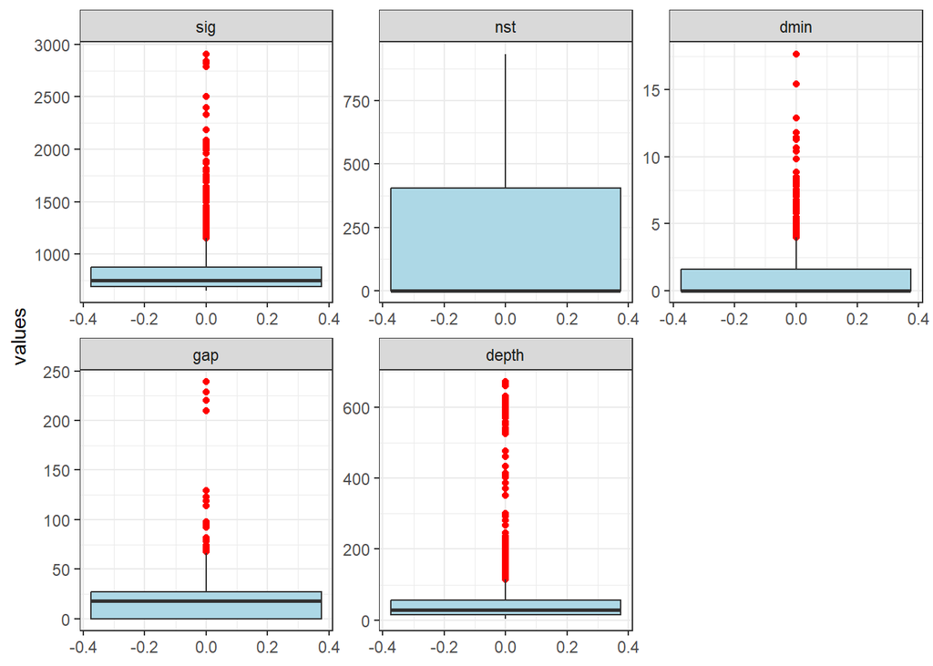

```r
tsunami_data %>%
  select(sig, nst, dmin, gap, depth) %>%
  stack() %>%
  ggplot(aes(y = values)) +
  geom_boxplot(outlier.color = "red", fill = "lightblue") +
  facet_wrap(~ ind, scales = "free") +
  theme_bw()
```

The boxplots reveal that many values are concentrated at zero, which represents the absence of tsunami-inducing factors rather than true outliers. While these zero-inflated distributions are unusual, they are meaningful in this context and should not be removed.

## 3.2 Distribution Analysis

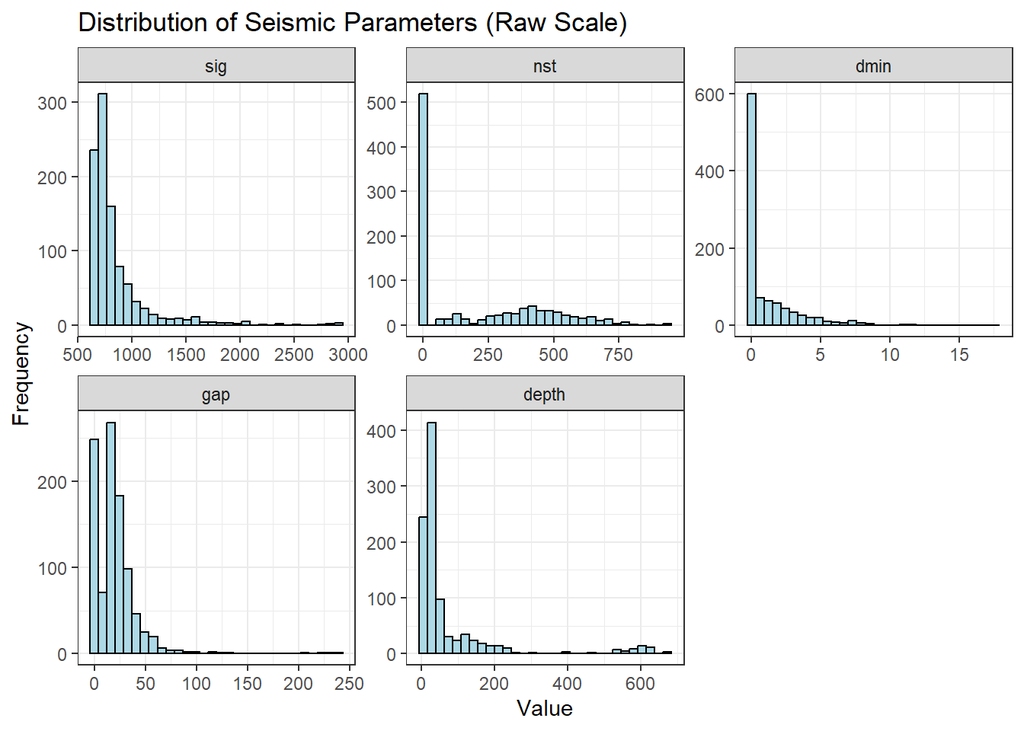

```r
tsunami_data %>%
  select(sig, nst, dmin, gap, depth) %>%
  stack() %>%
  ggplot(aes(x = values)) +
  geom_histogram(bins = 30, fill = "lightblue", color = "black") +
  facet_wrap(~ ind, scales = "free") +
  labs(
    title = "Distribution of Seismic Parameters (Raw Scale)",
    x = "Value",
    y = "Frequency"
  ) +
  theme_bw()
```

The raw distributions are highly right-skewed, suggesting that a logarithmic transformation would be appropriate. This is consistent with how earthquake magnitude is measured on the Richter scale (a logarithmic scale).

## 3.3 Logarithmic Transformation

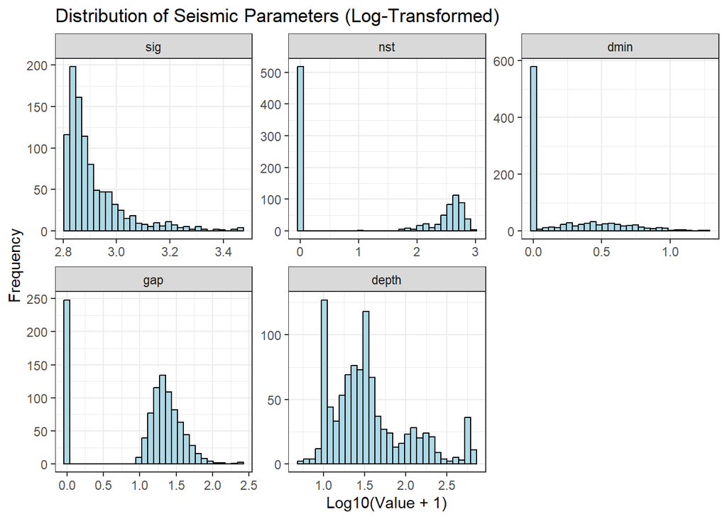

```r
# Apply log10 transformation to right-skewed variables
tsunami_data <- tsunami_data %>%
  mutate(across(c(sig, nst, gap, dmin, depth),
                ~ log10(.x + 1)))

# Visualize transformed distributions
tsunami_data %>%
  select(sig, nst, dmin, gap, depth) %>%
  stack() %>%
  ggplot(aes(x = values)) +
  geom_histogram(bins = 30, fill = "lightblue", color = "black") +
  facet_wrap(~ ind, scales = "free") +
  labs(
    title = "Distribution of Seismic Parameters (Log-Transformed)",
    x = "Log10(Value + 1)",
    y = "Frequency"
  ) +
  theme_bw()
```

## 3.4 Data Normalization

```r
normalized_tsunami_data <- tsunami_data %>%
  mutate(across(-tsunami, ~ scale(.x)))
```

Final step before applying any model.

# 4. Data Visualization

## 4.1 Correlation Analysis

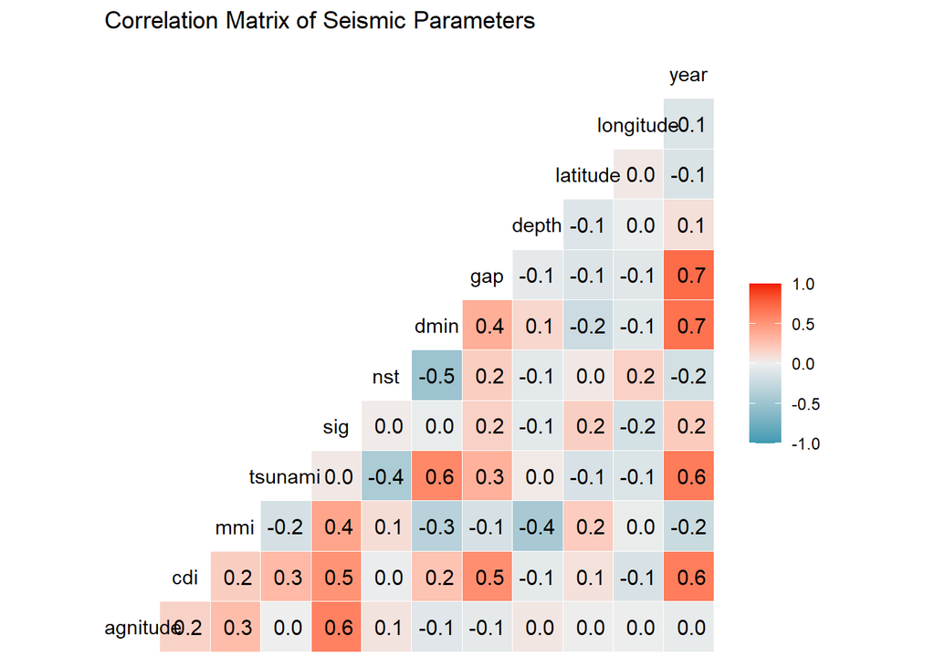

```r
ggcorr(normalized_tsunami_data, label = TRUE) +
  labs(title = "Correlation Matrix of Seismic Parameters")
```

## 4.2 Geospatial Visualization

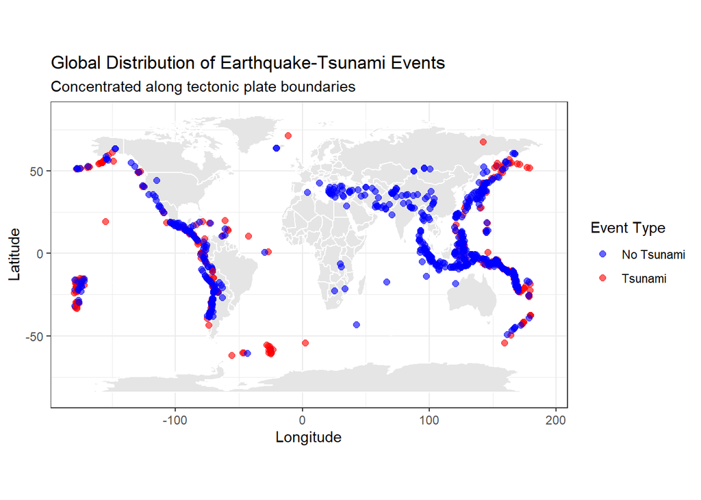

```r
world <- map_data("world")

tsunami_data %>%
  select(latitude, longitude, tsunami) %>%
  ggplot() +
  geom_polygon(
    data = world,
    aes(x = long, y = lat, group = group),
    fill = "gray90",
    color = "white"
  ) +
  geom_point(
    aes(x = longitude, y = latitude, color = factor(tsunami)),
    size = 2,
    alpha = 0.6
  ) +
  scale_color_manual(
    values = c("0" = "blue", "1" = "red"),
    labels = c("No Tsunami", "Tsunami"),
    name = "Event Type"
  ) +
  coord_fixed(1.3) +
  labs(
    title = "Global Distribution of Earthquake-Tsunami Events",
    subtitle = "Concentrated along tectonic plate boundaries",
    x = "Longitude",
    y = "Latitude"
  ) +
  theme_bw()
```

The plot clearly shows that earthquakes (and especially tsunamis) are concentrated along tectonic plate boundaries, particularly the Pacific Ring of Fire. The relationship between location and tsunami occurrence is non-linear and spatially clustered, which cannot be captured by simple linear regression.

# 5. Predictive Modeling

## 5.1 Linear Regression Analysis

```r
multi_tsunami <- lm(
  tsunami ~ cdi + mmi + sig + nst + dmin + gap + depth + latitude + longitude + year,
  data = tsunami_data
)

summary(multi_tsunami)
```

```
##
## Call:
## lm(formula = tsunami ~ cdi + mmi + sig + nst + dmin + gap + depth +
##     latitude + longitude + year, data = tsunami_data)
##
## Residuals:
##      Min       1Q   Median       3Q      Max
## -0.97212 -0.11799  0.02113  0.23324  0.86087
##
## Coefficients:
##               Estimate Std. Error t value Pr(>|t|)
## (Intercept) -7.922e+01  5.629e+00 -14.074  < 2e-16 ***
## cdi         -1.497e-02  5.041e-03  -2.971  0.00304 **
## mmi          1.576e-02  9.940e-03   1.586  0.11317
## sig         -2.493e-01  1.202e-01  -2.075  0.03825 *
## nst         -1.058e-01  1.081e-02  -9.781  < 2e-16 ***
## dmin        -1.416e-03  6.227e-02  -0.023  0.98186
## gap         -2.602e-02  2.763e-02  -0.942  0.34650
## depth       -4.368e-02  2.558e-02  -1.707  0.08807 .
## latitude    -6.473e-04  4.147e-04  -1.561  0.11886
## longitude   -5.702e-05  9.241e-05  -0.617  0.53735
## year         4.003e-02  2.813e-03  14.231  < 2e-16 ***
## ---
## Signif. codes:  0 '***' 0.001 '**' 0.01 '*' 0.05 '.' 0.1 ' ' 1
##
## Residual standard error: 0.3262 on 974 degrees of freedom
## Multiple R-squared:  0.5204, Adjusted R-squared:  0.5155
## F-statistic: 105.7 on 10 and 974 DF,  p-value: < 2.2e-16
```

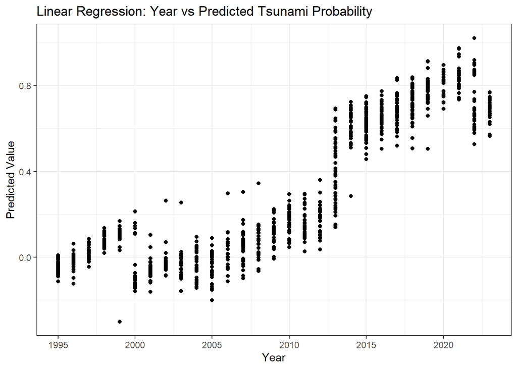

Linear regression predictions vs year

```r
pred <- predict(multi_tsunami)
qplot(
  tsunami_data$year,
  pred,
  main = "Linear Regression: Year vs Predicted Tsunami Probability",
  xlab = "Year",
  ylab = "Predicted Value"
) +
  theme_bw()
```

**Linear Regression Conclusion:** While linear regression provides initial insights into variable relationships, it is fundamentally inappropriate for binary outcomes. The year variable shows the clearest linear relationship, but the model produces predicted probabilities outside the valid [0,1] range. This indicates that logistic regression is necessary for proper probabilistic predictions.

## 5.2 Logistic Regression Model

```r
logistic_tsunami <- tsunami_data %>%
  glm(
    tsunami ~ cdi + mmi + sig + nst + dmin + gap + depth + latitude + longitude + year,
    data = .,
    family = binomial
  )

revised_logistic_tsunami <- tsunami_data %>%
  glm(
    tsunami ~ cdi + nst + dmin + year,
    data = .,
    family = binomial
  )

summary(revised_logistic_tsunami)
```

```
##
## Call:
## glm(formula = tsunami ~ cdi + nst + dmin + year, family = binomial,
##     data = .)
##
## Coefficients:
##               Estimate Std. Error z value Pr(>|z|)
## (Intercept) -600.32360   52.78967 -11.372  < 2e-16 ***
## cdi           -0.11713    0.03826  -3.062   0.0022 **
## nst           -0.72154    0.10338  -6.979 2.97e-12 ***
## dmin          -0.73018    0.46015  -1.587   0.1126
## year           0.29859    0.02630  11.353  < 2e-16 ***
## ---
## Signif. codes:  0 '***' 0.001 '**' 0.01 '*' 0.05 '.' 0.1 ' ' 1
##
## (Dispersion parameter for binomial family taken to be 1)
##
##     Null deviance: 1242.06  on 984  degrees of freedom
## Residual deviance:  642.75  on 980  degrees of freedom
## AIC: 652.75
##
## Number of Fisher Scoring iterations: 6
```

## 5.3 Model Evaluation Metrics

```r
# Calculate McFadden's Pseudo R-squared
rdev <- summary(revised_logistic_tsunami)$deviance
nulldev <- summary(revised_logistic_tsunami)$null.deviance
mcfadden_r2 <- 1 - (rdev / nulldev)

# Mean Squared Error
predicted_probs <- predict(revised_logistic_tsunami, type = "response")
actual <- tsunami_data$tsunami
mse <- mean((actual - predicted_probs)^2)

# Log-Loss
predicted_probs <- pmin(pmax(predicted_probs, 1e-15), 1 - 1e-15)
log_loss <- -mean(actual * log(predicted_probs) + (1 - actual) * log(1 - predicted_probs))
```

**Model Performance Analysis:**

McFadden’s Pseudo R² = 0.4825: This value indicates excellent model fit. For binary logistic regression, values greater than 0.2 are considered excellent, and values greater than 0.4 are exceptional. Our model explains approximately 48.3% of the deviance in tsunami probability, which is outstanding for a binary outcome model.

Mean Squared Error = 0.1073: This indicates good predictive accuracy on the probability scale.

Log-Loss = 0.3263: This is the appropriate loss function for logistic models. Lower values indicate better probabilistic predictions. Perfect predictions yield log-loss = 0.

## 5.4 Odds Ratios Interpretation

```r
revised_logistic_summary <- summary(revised_logistic_tsunami)
multiplicative_effects <- exp(revised_logistic_summary$coefficients[-1, "Estimate"])
print(round(multiplicative_effects, 4))
```

```
##    cdi    nst   dmin   year
## 0.8895 0.4860 0.4818 1.3480
```

**Interpretation of Predictor Effects:**